# EasyVisa Project

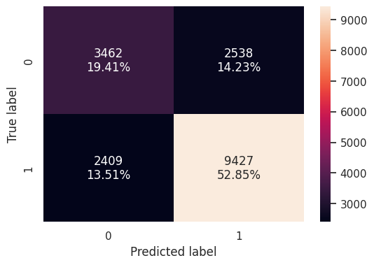

```python
# to create the confusion matrix for X_train1 and y_train with optimal_threshold_curve as threshold
confusion_matrix_statsmodels(
    lg2, X_train1, y_train, threshold=optimal_threshold_curve
)
```

- True Positives (TP): 9,427 (52.85%)
  - Model predicted the right certified candidates 52.85% of the data.
- False Negatives (FN): 2,409 (13.51%)
  - Model predicted denied candidates when the candidate was certified 13.51% of of the data.
- False Positives (FP): 2,538 (14.23%)
  - Model predicted the candidate would be certified when they were denied for 14.23% of the data.
- True Negatives (TN): 3,462 (19.41%)
  - Model predicted the candidate would be denied when they were actually denied for 19.41% of the data.
- Model was able to predict 72.26% of the data into the appropriate classification.

```python
# checking model performance for this model
log_reg_model_train_perf_threshold_curve = model_performance_classification_statsmodels(
    lg2, X_train1, y_train, threshold=optimal_threshold_curve
)
print("Training performance:")
log_reg_model_train_perf_threshold_curve
```

```
Training performance:
```

|  | Accuracy | Recall | Precision | F1 |
| --- | --- | --- | --- | --- |
| 0 | 0.72264 | 0.79647 | 0.78788 | 0.79215 |

- Training Performance:
  - Accuracy: 72.26%
  - Recall: 79.65%
  - Precision: 78.79%
  - F1: 79.22%
- After identifying the optimal threshold curve, recall becomes 79.65% which seems more reliable.

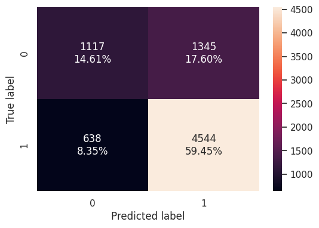

```python
# to create confusion matrix for X_test1 and y_test
confusion_matrix_statsmodels(lg2, X_test1, y_test)
```

- True Positives (TP): 4,544 (59.45%)
  - Model predicted the right certified candidates 59.45% of the data.
- False Negatives (FN): 638 (8.35%)
  - Model predicted denied candidates when the candidate was certified 8.35% of of the data.
- False Positives (FP): 1,345 (17.60%)
  - Model predicted the candidate would be certified when they were denied for 17.60% of the data.
- True Negatives (TN): 1,117 (14.61%)
  - Model predicted the candidate would be denied when they were actually denied for 14.61% of the data.
- Model was able to predict 74.06% of the data into the appropriate classification.

```python
# checking model performance for this model
log_reg_model_test_perf = model_performance_classification_statsmodels(lg2, X_test1, y_test)

print("Test performance:")
log_reg_model_test_perf
```

```
Test performance:
```

|  | Accuracy | Recall | Precision | F1 |
| --- | --- | --- | --- | --- |
| 0 | 0.74058 | 0.87688 | 0.77161 | 0.82088 |

- Test Performance:
  - Accuracy: 74.06%
  - Recall: 87.69%
  - Precision: 77.16%
  - F1: 82.09%

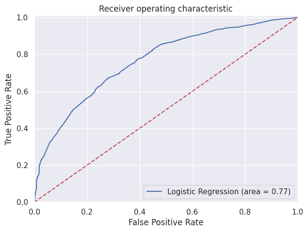

```python
# ROC AUC on testing set
logit_roc_auc_train = roc_auc_score(y_test, lg2.predict(X_test1))
fpr, tpr, thresholds = roc_curve(y_test, lg2.predict(X_test1))
plt.figure(figsize=(7, 5))
plt.plot(fpr, tpr, label="Logistic Regression (area = %0.2f)" % logit_roc_auc_train)
plt.plot([0, 1], [0, 1], "r--")
plt.xlim([0.0, 1.0])
plt.ylim([0.0, 1.01])
plt.xlabel("False Positive Rate")
plt.ylabel("True Positive Rate")
plt.title("Receiver operating characteristic")
plt.legend(loc="lower right")
plt.show()
```

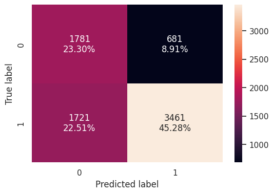

```python
# to create confusion matrix for X_test1 and y_test using optimal_threshold_auc_roc as threshold
confusion_matrix_statsmodels(lg2, X_test1, y_test, threshold=optimal_threshold_auc_roc)
```

- True Positives (TP): 3,461 (45.28%)
  - Model predicted the right certified candidates for 45.28% of the data.
- False Negatives (FN): 1,721 (22.51%)
  - Model predicted denied candidates when the candidate was certified for 22.51% of the data.
- False Positives (FP): 681 (8.91%)
  - Model predicted the candidate would be certified when they were denied for 8.91% of the data.
- True Negatives (TN): 1,781 (23.30%)
  - Model predicted the candidate would be denied when they were actually denied for 23.30% of the data.
- Model was able to predict 68.58% of the data into the appropriate classification.

```python
# checking model performance for this model using optimal_threshold_auc_roc as threshold
log_reg_model_test_perf_threshold_auc_roc = model_performance_classification_statsmodels(
    lg2, X_test1, y_test, threshold=optimal_threshold_auc_roc
)
print("Test performance:")
log_reg_model_test_perf_threshold_auc_roc
```

```
Test performance:
```

|  | Accuracy | Recall | Precision | F1 |
| --- | --- | --- | --- | --- |
| 0 | 0.68577 | 0.66789 | 0.83559 | 0.74239 |

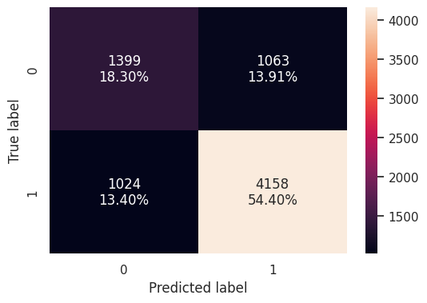

```python
# to create confusion matrix for X_test1 and y_test using optimal_threshold_curve as threshold
confusion_matrix_statsmodels(lg2, X_test1, y_test, threshold=optimal_threshold_curve)
```

- True Positives (TP): 4,158 (54.40%)
  - Model predicted the right certified candidates for 54.40% of the data.
- False Negatives (FN): 1,024 (13.40%)
  - Model predicted denied candidates when the candidate was certified for 13.40% of the data.
- False Positives (FP): 1,063 (13.91%)
  - Model predicted the candidate would be certified when they were denied for 13.91% of the data.
- True Negatives (TN): 1,399 (18.30%)
  - Model predicted the candidate would be denied when they were actually denied for 18.30%% of the data.
- Model was able to predict 72.70% of the data into the appropriate classification.

```python
# checking model performance for this model using optimal_threshold_curve as threshold
log_reg_model_test_perf_threshold_curve = model_performance_classification_statsmodels(
    lg2, X_test1, y_test, threshold=optimal_threshold_curve
)
print("Test performance:")
log_reg_model_test_perf_threshold_curve
```

```
Test performance:
```

|  | Accuracy | Recall | Precision | F1 |
| --- | --- | --- | --- | --- |
| 0 | 0.72698 | 0.80239 | 0.79640 | 0.79938 |

- Test Performance:
  - Accuracy: 72.70%
  - Recall: 80.24%
  - Precision: 79.64%
  - F1: 79.94%
- Recall is 80.24% which provides for a stronger sense of reliability in the model.

```python
# training performance comparison

models_train_comp_df = pd.concat(
    [
        log_reg_model_train_perf.T,
        log_reg_model_train_perf_threshold_auc_roc.T,
        log_reg_model_train_perf_threshold_curve.T,
    ],
    axis=1,
)
models_train_comp_df.columns = [
    "Logistic Regression-default Threshold",
    "Logistic Regression-0.697 Threshold",
    "Logistic Regression-0.62 Threshold",
]

print("Training performance comparison:")
models_train_comp_df
```

```
Training performance comparison:
```

|  | Logistic Regression-default Threshold | Logistic Regression-0.697 Threshold | Logistic Regression-0.62 Threshold |
| --- | --- | --- | --- |
| Accuracy | 0.73699 | 0.68900 | 0.72264 |
| Recall | 0.87673 | 0.66543 | 0.79647 |
| Precision | 0.76251 | 0.83229 | 0.78788 |
| F1 | 0.81564 | 0.73957 | 0.79215 |

```python
# testing performance comparison

models_test_comp_df = pd.concat(
    [
        log_reg_model_test_perf.T,
        log_reg_model_test_perf_threshold_auc_roc.T,
        log_reg_model_test_perf_threshold_curve.T,
    ],
    axis=1,
)
models_test_comp_df.columns = [
    "Logistic Regression-default Threshold (0.5)",
    "Logistic Regression-0.697 Threshold",
    "Logistic Regression-0.62 Threshold",
]

print("Test set performance comparison:")
models_test_comp_df
```

```
Test set performance comparison:
```

|  | Logistic Regression-default Threshold (0.5) | Logistic Regression-0.697 Threshold | Logistic Regression-0.62 Threshold |
| --- | --- | --- | --- |
| Accuracy | 0.74058 | 0.68577 | 0.72698 |
| Recall | 0.87688 | 0.66789 | 0.80239 |
| Precision | 0.77161 | 0.83559 | 0.79640 |
| F1 | 0.82088 | 0.74239 | 0.79938 |

- Logistic Regression model with a threshold of 0.62 has the second highest F1 (79.94%) which is close enough to the highest F1 (82.10%).
- Logistic Regression model with a threshold of 0.62 has a Recall of 80.24% which is ~7% lower than the default threshold at 87.69%.
- The Test Performance with the threshold that is likely to provide the lowest False Negatives and False Positives while also being less sensitive to discrepancies in data is the Logisitc Regression-0.62 Threshold.

## Decision Tree - Model Building and Hyperparameter Tuning

## Building bagging and boosting models

```python
# defining a function to compute different metrics to check performance of a classification model built using sklearn
def model_performance_classification_sklearn(model, predictors, target):
    """
    Function to compute different metrics to check classification model performance

    model: classifier
    predictors: independent variables
    target: dependent variable
    """

    # predicting using the independent variables
    pred = model.predict(predictors)

    acc = accuracy_score(target, pred)  # to compute Accuracy
    recall = recall_score(target, pred)  # to compute Recall
    precision = precision_score(target, pred)  # to compute Precision
    f1 = f1_score(target, pred)  # to compute F1-score

    # creating a dataframe of metrics
    df_perf = pd.DataFrame(
        {"Accuracy": acc, "Recall": recall, "Precision": precision, "F1": f1,},
        index=[0],
    )

    return df_perf
```

```python
def confusion_matrix_sklearn(model, predictors, target):
    """
    To plot the confusion_matrix with percentages

    model: classifier
    predictors: independent variables
    target: dependent variable
    """
    y_pred = model.predict(predictors)
    cm = confusion_matrix(target, y_pred)
    labels = np.asarray(
        [
            ["{0:0.0f}".format(item) + "\n{0:.2%}".format(item / cm.flatten().sum())]
            for item in cm.flatten()
        ]
    ).reshape(2, 2)

    plt.figure(figsize=(6, 4))
    sns.heatmap(cm, annot=labels, fmt="")
    plt.ylabel("True label")
    plt.xlabel("Predicted label")
```

```python
# function to compute adjusted R-squared
def adj_r2_score(predictors, targets, predictions):
    r2 = r2_score(targets, predictions)
    n = predictors.shape[0]
    k = predictors.shape[1]
    return 1 - ((1 - r2) * (n - 1) / (n - k - 1))


# function to compute MAPE
def mape_score(targets, predictions):
    return np.mean(np.abs(targets - predictions) / targets) * 100


# function to compute different metrics to check performance of a regression model
def model_performance_regression(model, predictors, target):
    """
    Function to compute different metrics to check regression model performance

    model: regressor
    predictors: independent variables
    target: dependent variable
    """

    # predicting using the independent variables
    pred = model.predict(predictors)

    r2 = r2_score(target, pred)  # to compute R-squared
    adjr2 = adj_r2_score(predictors, target, pred)  # to compute adjusted R-squared
    rmse = np.sqrt(mean_squared_error(target, pred))  # to compute RMSE
    mae = mean_absolute_error(target, pred)  # to compute MAE
    mape = mape_score(target, pred)  # to compute MAPE

    # creating a dataframe of metrics
    df_perf = pd.DataFrame(
        {
            "RMSE": rmse,
            "MAE": mae,
            "R-squared": r2,
            "Adj. R-squared": adjr2,
            "MAPE": mape,
        },
        index=[0],
    )

    return df_perf
```

```python
#  Function to calculate r2_score and RMSE on train and test data
def get_model_score(model, flag=True):
    '''
    model : classifier to predict values of X

    '''
    # defining an empty list to store train and test results
    score_list=[]

    pred_train = model.predict(X_train)
    pred_test = model.predict(X_test)

    train_r2=metrics.r2_score(y_train,pred_train)
    test_r2=metrics.r2_score(y_test,pred_test)
    train_rmse=np.sqrt(metrics.mean_squared_error(y_train,pred_train))
    test_rmse=np.sqrt(metrics.mean_squared_error(y_test,pred_test))

    #Adding all scores in the list
    score_list.extend((train_r2,test_r2,train_rmse,test_rmse))

    # If the flag is set to True then only the following print statements will be dispayed, the default value is True
    if flag==True:
        print("R-sqaure on training set : ",metrics.r2_score(y_train,pred_train))
        print("R-square on test set : ",metrics.r2_score(y_test,pred_test))
        print("RMSE on training set : ",np.sqrt(metrics.mean_squared_error(y_train,pred_train)))
        print("RMSE on test set : ",np.sqrt(metrics.mean_squared_error(y_test,pred_test)))

    # returning the list with train and test scores
    return score_list
```